# Abstract

In this experiment, I have tried to implement results Deep Q-network as a part of Udacity navigation project. Based on the episodic iteration I try to analyse the performance.

# Overview

For this project, you will train an agent to navigate (and collect bananas!) in a large, square world.

A reward of +1 is provided for collecting a yellow banana, and a reward of -1 is provided for collecting a blue banana. Thus, the goal of your agent is to collect as many yellow bananas as possible while avoiding blue bananas.

The state space has 37 dimensions and contains the agent's velocity, along with ray-based perception of objects around the agent's forward direction. Given this information, the agent has to learn how to best select actions. Four discrete actions are available, corresponding to:

- 0 - move forward.
- 1 - move backward.
- 2 - turn left.
- 3 - turn right.

The task is episodic, and in order to solve the environment, your agent must get an average score of +13 over 100 consecutive episodes.

# Output Analysis

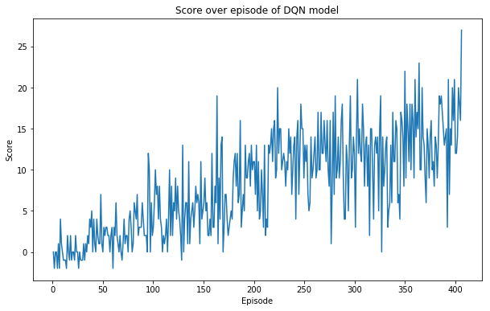

```python
from IPython.display import Image
from IPython.core.display import HTML
Image(filename = "img.png")
```

As we can observe from the figure, the agent tries to achieve better result after 50th episode. Because it tries to explore the environment. Then we can see increasing trend till 250th episode. After that the agent the score remains a bit constant. Again this might be due to the exploration. At the end we can see the agent is scoring again.